# Multi-Linear Analyses of Pricing from [King’s County Housing Data](http://your.kingcounty.gov/assessor/eRealProperty/ResGlossaryOfTerms.html)

David Sawyer

March 03, 2018

# 1 Introduction

Housing prices is a complicated topic that influences some of the most important investments a person or persons make. There are many variables that effect how a house is priced and if the house is priced at the wrong point it can mean a house not being sold or a purchase that could make for a bad investment. This makes pricing a pivotal topic worthy of developing solutions. The point of developing this model is to help those involved in the housing market to find insights on other ways to properly assess the value of a home.

The model I have developed to help bring insight to housing values uses Data from the [King’s County website](http://your.kingcounty.gov/assessor/eRealProperty/ResGlossaryOfTerms.html) . The data originally contains 17384 observations and 21 variables. In this paper, the modifications of this data and the details of the model will be covered in the following sections.

[figure not shown]

# 2 Methods

## 2.1 Data Collection

|  | date | price | bedrooms | bathrooms | sqft_living | sqft_lot | floors | waterfront | view | condition | grade | sqft_above | yr_built | yr_renovated | zipcode | lat | long | sqft_living15 | sqft_lot15 |
| --- | --- | --- | --- | --- | --- | --- | --- | --- | --- | --- | --- | --- | --- | --- | --- | --- | --- | --- | --- |
| 1 | 2014-10-13 | 221900 | 3 | 1 | 1180 | 5650 | 1 | No | 0 | average | 7 | 1180 | 1955-09-01 | 1955-09-01 | 98178 | 47.5112 | -122.257 | 1340 | 5650 |
| 2 | 2014-12-09 | 538000 | 3 | 2.25 | 2570 | 7242 | 2 | No | 0 | average | 7 | 2170 | 1951-09-01 | 1991-09-01 | 98125 | 47.721 | -122.319 | 1690 | 7639 |
| 3 | 2015-02-25 | 180000 | 2 | 1 | 770 | 10000 | 1 | No | 0 | average | 6 | 770 | 1933-09-01 | 1933-09-01 | 98028 | 47.7379 | -122.233 | 2720 | 8062 |
| 4 | 2014-12-09 | 604000 | 4 | 3 | 1960 | 5000 | 1 | No | 0 | very good | 7 | 1050 | 1965-09-01 | 1965-09-01 | 98136 | 47.5208 | -122.393 | 1360 | 5000 |
| 5 | 2015-02-18 | 510000 | 3 | 2 | 1680 | 8080 | 1 | No | 0 | average | 8 | 1680 | 1987-09-01 | 1987-09-01 | 98074 | 47.6168 | -122.045 | 1800 | 7503 |
| 6 | 2014-05-12 | 1225000 | 4 | 4.5 | 5420 | 101930 | 1 | No | 0 | average | 11 | 3890 | 2001-09-01 | 2001-09-01 | 98053 | 47.6561 | -122.005 | 4760 | 101930 |
| 7 | 2014-06-27 | 257500 | 3 | 2.25 | 1715 | 6819 | 2 | No | 0 | average | 7 | 1715 | 1995-09-01 | 1995-09-01 | 98003 | 47.3097 | -122.327 | 2238 | 6819 |
| 8 | 2015-01-15 | 291850 | 3 | 1.5 | 1060 | 9711 | 1 | No | 0 | average | 7 | 1060 | 1963-09-01 | 1963-09-01 | 98198 | 47.4095 | -122.315 | 1650 | 9711 |
| 9 | 2015-04-15 | 229500 | 3 | 1 | 1780 | 7470 | 1 | No | 0 | average | 7 | 1050 | 1960-09-01 | 1960-09-01 | 98146 | 47.5123 | -122.337 | 1780 | 8113 |
| 10 | 2015-03-12 | 323000 | 3 | 2.5 | 1890 | 6560 | 2 | No | 0 | average | 7 | 1890 | 2003-09-01 | 2003-09-01 | 98038 | 47.3684 | -122.031 | 2390 | 7570 |

[output cut: 90 more lines]

## 2.2 Exploritory Analysis

The data was anylized using methods defined in the ISLR textbook (James et al. (2013)).These methods included summarization, annova testing, residual plot analysis, and intuitive approaches to interaction term development.

## 2.3 Statistical Modeling

The model is based on multi-linear modeling. The methods used for this modeling were pulled from the ISLR(James et al. (2013)) text book ad a paper by [Iain Pardoe](https://ww2.amstat.org/publications/jse/v16n2/datasets.pardoe.html).

## 2.4 Reproducibility

The data in this paper is accessible from the links provided above. The methods used for getting to the model can also be found in the given links as long as those links are valid. The actual model can be re-run by downloading the file from this [link](https://raw.githubusercontent.com/STAT-ATA-ASU/Sawyer-David/master/Assignments2017/KingCounty/RmdFiles/TheScript.rmd?token=AYBNW4wu3x6wZn6qYoqsV6sh2wgpVUutks5ZCZaCwA%3D%3D). It is compatible with the current R-Studio package and current version of `R` (3.3.3). The libraries used within this project (both the paper and the model development) were `car` (Fox and Weisberg 2015), `ggplot2` (Wickham and Chang 2016), `knitr` (Xie 2016c), `DT`(Xie 2016b), `rmarkdown` (Allaire et al. 2016), and `bookdown` (Xie 2016a). These libraries will need to be installed to run the .Rmd file.

# 3 Results

The final model developed for predicting the prices was built off of several different predictors. The predictors included can be broke into two categories, home attributes and location. The predictors related to the home’s attributes are the sqare footage of the lot (`sqft_living`), the sqare footage of the home (`sqft_living`), the average of the square footage of the surrounding 15 lots (`sqft_lot15`), the average of the square footage of the home for the surrounding 15 homes (`sqft_living15`), the grade of the construction of the homes (`grade`), the condition of the home (`condition`), the year the home was built (`yr_built`) and the year the home was renovated (`yr_renovated`). The location data is the zip codes of the home (`zipcode`), the latitude (`lat`), and the longitude (`long`). The final model has taken on the form:

$$\begin{align}
\text{Price} &=\beta_{0} + \beta_{1}(\text{sqft_living}^{2})+ \beta_{3}(\text{sqft_living:sqft_lot:zipcode}) \\
&+ \beta_{4}(\text{sqft_living15:sqft_lot15}) + \beta_{5}(\text{ sqft_living:floors:sqft_living15:zipcode}) \\
&+ \beta_{6}(\text{sqft_lot:sqft_lot15:zipcode}) + \beta_{7}(\text{condition:grade}) \\
&+ \beta_{8}(\text{view:waterfront:zipcode}) + \beta_{9}(\text{floors:sqft_living:zipcode}) \\
&+ \beta_{10}(\text{yr_built:yr_renovated:zipcode}) +\beta_{11}(\text{lat:long:zipcode}) + \beta_{12}(\text{zipcode98199}) \\ &+ \beta_{13}(\text{zipcode98198}) + \beta_{14}(\text{zipcode98177}) + \beta_{15}(\text{zipcode98144}) \\
&+ \beta_{16}(\text{zipcode98136}) + \beta_{17}(\text{zipcode98126}) + \beta_{18}(\text{zipcode98125}) \\
&+ \beta_{19}(\text{zipcode98122}) + \beta_{20}(\text{zipcode98119}) + \beta_{21}(\text{zipcode98118}) \\
&+ \beta_{22}(\text{zipcode98117}) + \beta_{23}(\text{zipcode98116}) + \beta_{24}(\text{zipcode98115}) \\
&+ \beta_{25}(\text{zipcode98112}) + \beta_{26}(\text{zipcode98109}) + \beta_{27}(\text{zipcode98108}) \\
&+ \beta_{28}(\text{zipcode98107}) + \beta_{29}(\text{zipcode98106}) + \beta_{30}(\text{zipcode98105}) \\
&+ \beta_{31}(\text{zipcode98103}) + \beta_{32}(\text{zipcode98102}) + \beta_{33}(\text{zipcode98004}) \\
&+ \beta_{31}(\text{zipcode98005}) + \beta_{34}(\text{zipcode98006}) + \beta_{35}(\text{zipcode98007}) \\
&+ \beta_{36}(\text{zipcode98008}) + \beta_{37}(\text{zipcode98010}) + \beta_{38}(\text{zipcode98014}) \\
&+ \beta_{39}(\text{zipcode 98019}) + \beta_{40}(\text{zipcode98022}) + \beta_{41}(\text{zipcode98023}) \\
&+ \beta_{42}(\text{zipcode98024}) + \beta_{43}(\text{zipcode98027}) + \beta_{44}(\text{zipcode 98029}) \\
&+ \beta_{45}(\text{zipcode98033})+ \beta_{46}(\text{zipcode 98034}) + \beta_{47}(\text{zipcode98038}) \\
&+ \beta_{48}(\text{zipcode98039}) + \beta_{49}(\text{zipcode98040}) + \beta_{50}(\text{zipcode98045}) \\
&+ \beta_{51}(\text{zipcode98052}) + \beta_{52}(\text{zipcode 98053}) + \beta_{53}(\text{zipcode98056}) \\
&+ \beta_{54}(\text{zipcode98058}) + \beta_{55}(\text{zipcode98059}) + \beta_{56}(\text{zipcode98065}) \\
&+ \beta_{57}(\text{zipcode98070}) + \beta_{58}(\text{zipcode98072}) + \beta_{59}(\text{zipcode98074}) \\
&+ \beta_{60}(\text{zipcode98075}) + \beta_{61}(\text{gradegrade11}) + \beta_{62}(\text{gradegrade12}) \\
&+ \beta_{63}(\text{gradegrade13}) + \beta_{64}(\text{date}) + \beta_{65}(\text{bedrooms}) + \beta_{66}(\text{bathrooms}) \\ &+ \beta_{67}(\text{sqft_living}) + \beta_{68}(\text{sqft_lot}) + \beta_{69}(\text{floors}) \\
&+ \beta_{70}(\text{waterfrontYes}) + \beta_{71}(\text{view}) + \beta_{72}(\text{conditionfair}) \\
&+ \beta_{73}(\text{conditiongood}) + \beta_{74}(\text{conditionverygood}) + \beta_{75}(\text{conditionaverage}) \\
&+ \beta_{76}(\text{yr_built}) + \beta_{77}(\text{yr_renovated} + \beta_{78}(\text{sqft_above}) + \varepsilon
\nonumber
\tag{3.1}
\end{align}$$

The first addition to the model was to `sqft_living`. When viewing the residual plot the line fitted seemed to take on a quadratic relationship. This was convincing enough to add `poly(sqft_living, 2)`. The residual plot was as follows:

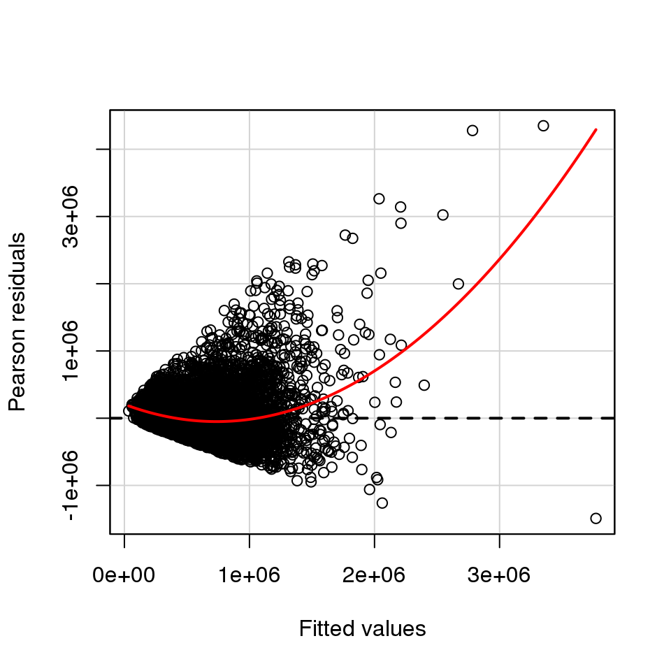

Figure 3.1: Residual Plot of the residuals on the `sqft_living`

The term `sqft_living:sqft_lot:zipcode` covers how the ratio between a homes size and its lot affects the price from zip code to zip code. The interaction term that represents the interaction between the square footage of the 15 surrounding homes and the sqare footage of the 15 surrounding lots is `sqft_living15:sqft_lot15`. In addition to accounting for that ratio the term, `sqft_living:floors:sqft_living15:zipcode`, adds information on how a homes square footage and its distribution (amount of floors) interact with the average square footage of the surrounding 15 homes from zip code to zip code. A similar interaction term is `sqft_lot:sqft_lot15:zipcode`, which covers how a lot’s size compared to its neighbors in different zip codes affects price. The `grade` of construction may only matter depending on the condition and so the term `condition:grade` adds this to the model. The term `view:waterfront:zipcode` represents the interaction between whether a term has a view and is on a waterfront from zip code to zip code. An obvious term included in this is the affect floors and square footage of a home have depending on its zip code on pricing, `loors:sqft_living:zipcode` represents this idea. The term `yr_built:yr_renovated:zipcode` describes the interaction between the year a home was built or renovated in a given zip code. The final interaction term in the model is `lat:long:zipcode`. This term represents the geological location of a home and its interaction with a given zip code. The next set of dummy varialbles that follow the form `zipcode9XXXX` are dummy variables that measure the difference between being in the particular zip code and not being in that zip code. This is similar to the `gradeXX`, `conditionXXX`, `view`, and `waterfrontYes`. These variables cover the difference between being in the given category and not being in that category. The final result is a model that produces the following residual plot:

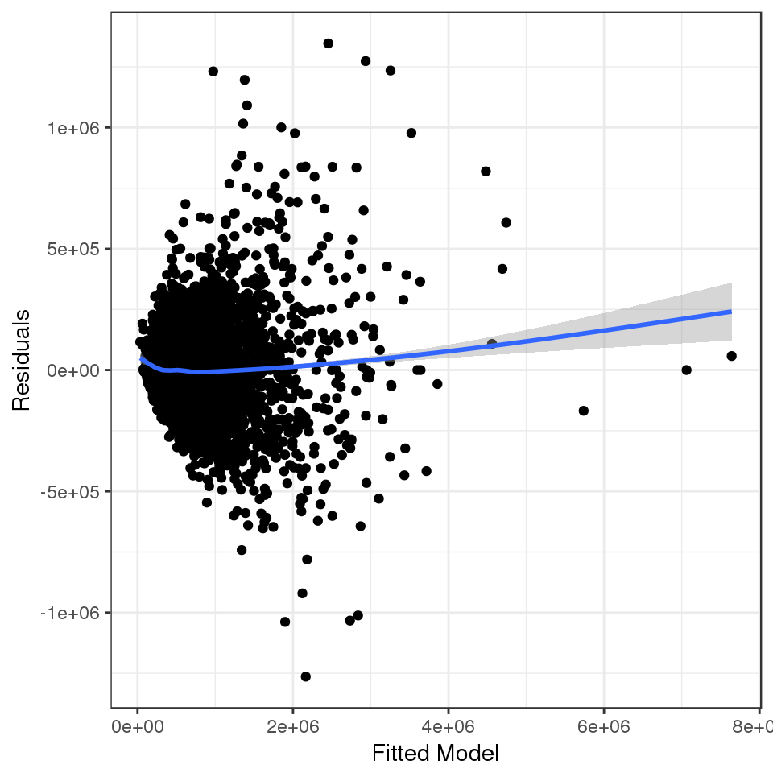

Figure 3.2: Residual Plot of the final model

The line seems to fit to the model quite well. A summary of the items seems to be the next logical step.

Table 3.1: ANOVA table for the full model fit using ordinary least squares

|  | Df | Sum Sq | Mean Sq | F value | Pr(>F) |
| --- | --- | --- | --- | --- | --- |
| date | 1 | 2.995570e+10 | 2.995570e+10 | 2.5341 | 0.1114 |
| bedrooms | 1 | 2.324877e+14 | 2.324877e+14 | 19667.6064 | 0.0000 |
| bathrooms | 1 | 4.228530e+14 | 4.228530e+14 | 35771.8041 | 0.0000 |
| sqft_living | 1 | 5.581620e+14 | 5.581620e+14 | 47218.4506 | 0.0000 |
| sqft_lot | 1 | 3.869380e+12 | 3.869380e+12 | 327.3353 | 0.0000 |
| floors | 1 | 9.048310e+10 | 9.048310e+10 | 7.6545 | 0.0057 |
| waterfront | 1 | 8.304425e+13 | 8.304425e+13 | 7025.2376 | 0.0000 |
| view | 1 | 3.889210e+13 | 3.889210e+13 | 3290.1283 | 0.0000 |
| condition | 4 | 1.634145e+13 | 4.085361e+12 | 345.6065 | 0.0000 |
| sqft_above | 1 | 1.520941e+11 | 1.520941e+11 | 12.8666 | 0.0003 |
| yr_built | 1 | 7.410391e+13 | 7.410391e+13 | 6268.9177 | 0.0000 |
| yr_renovated | 1 | 1.125202e+11 | 1.125202e+11 | 9.5188 | 0.0020 |
| lat | 1 | 1.358121e+14 | 1.358121e+14 | 11489.2059 | 0.0000 |
| long | 1 | 6.758613e+12 | 6.758613e+12 | 571.7537 | 0.0000 |
| sqft_living15 | 1 | 1.513523e+13 | 1.513523e+13 | 1280.3844 | 0.0000 |
| sqft_lot15 | 1 | 1.296605e+12 | 1.296605e+12 | 109.6880 | 0.0000 |
| I(zipcode == 98004) | 1 | 8.067155e+13 | 8.067155e+13 | 6824.5157 | 0.0000 |
| I(zipcode == 98005) | 1 | 1.377692e+12 | 1.377692e+12 | 116.5476 | 0.0000 |
| I(zipcode == 98006) | 1 | 4.563358e+12 | 4.563358e+12 | 386.0432 | 0.0000 |
| I(zipcode == 98007) | 1 | 5.637566e+11 | 5.637566e+11 | 47.6917 | 0.0000 |
| I(zipcode == 98008) | 1 | 1.804602e+12 | 1.804602e+12 | 152.6626 | 0.0000 |
| I(zipcode == 98010) | 1 | 4.926279e+11 | 4.926279e+11 | 41.6745 | 0.0000 |
| I(zipcode == 98014) | 1 | 4.268805e+11 | 4.268805e+11 | 36.1125 | 0.0000 |
| I(zipcode == 98019) | 1 | 3.557203e+12 | 3.557203e+12 | 300.9263 | 0.0000 |
| I(zipcode == 98022) | 1 | 1.464498e+12 | 1.464498e+12 | 123.8912 | 0.0000 |
| I(zipcode == 98023) | 1 | 1.370775e+12 | 1.370775e+12 | 115.9625 | 0.0000 |
| I(zipcode == 98024) | 1 | 2.306642e+11 | 2.306642e+11 | 19.5133 | 0.0000 |
| I(zipcode == 98027) | 1 | 9.327784e+11 | 9.327784e+11 | 78.9096 | 0.0000 |
| I(zipcode == 98029) | 1 | 2.672631e+12 | 2.672631e+12 | 226.0947 | 0.0000 |
| I(zipcode == 98033) | 1 | 6.439629e+12 | 6.439629e+12 | 544.7689 | 0.0000 |
| I(zipcode == 98034) | 1 | 9.326293e+11 | 9.326293e+11 | 78.8970 | 0.0000 |
| I(zipcode == 98038) | 1 | 2.043273e+11 | 2.043273e+11 | 17.2853 | 0.0000 |
| I(zipcode == 98039) | 1 | 4.462852e+13 | 4.462852e+13 | 3775.4084 | 0.0000 |
| I(zipcode == 98040) | 1 | 2.680279e+13 | 2.680279e+13 | 2267.4173 | 0.0000 |
| I(zipcode == 98045) | 1 | 3.153016e+12 | 3.153016e+12 | 266.7335 | 0.0000 |
| I(zipcode == 98052) | 1 | 9.118678e+11 | 9.118678e+11 | 77.1407 | 0.0000 |
| I(zipcode == 98053) | 1 | 3.861112e+11 | 3.861112e+11 | 32.6636 | 0.0000 |
| I(zipcode == 98056) | 1 | 7.972103e+10 | 7.972103e+10 | 6.7441 | 0.0094 |
| I(zipcode == 98058) | 1 | 1.255005e+11 | 1.255005e+11 | 10.6169 | 0.0011 |
| I(zipcode == 98059) | 1 | 8.051031e+09 | 8.051031e+09 | 0.6811 | 0.4092 |
| I(zipcode == 98065) | 1 | 1.823808e+11 | 1.823808e+11 | 15.4287 | 0.0001 |
| I(zipcode == 98070) | 1 | 1.995826e+12 | 1.995826e+12 | 168.8396 | 0.0000 |
| I(zipcode == 98072) | 1 | 1.408190e+12 | 1.408190e+12 | 119.1277 | 0.0000 |
| I(zipcode == 98074) | 1 | 1.609853e+12 | 1.609853e+12 | 136.1877 | 0.0000 |
| I(zipcode == 98075) | 1 | 3.465874e+12 | 3.465874e+12 | 293.2002 | 0.0000 |
| I(zipcode == 98102) | 1 | 6.407229e+12 | 6.407229e+12 | 542.0280 | 0.0000 |
| I(zipcode == 98103) | 1 | 8.980033e+11 | 8.980033e+11 | 75.9678 | 0.0000 |
| I(zipcode == 98105) | 1 | 9.130612e+12 | 9.130612e+12 | 772.4161 | 0.0000 |
| I(zipcode == 98106) | 1 | 6.572116e+11 | 6.572116e+11 | 55.5977 | 0.0000 |
| I(zipcode == 98107) | 1 | 7.957641e+11 | 7.957641e+11 | 67.3187 | 0.0000 |
| I(zipcode == 98108) | 1 | 5.394654e+11 | 5.394654e+11 | 45.6368 | 0.0000 |
| I(zipcode == 98109) | 1 | 4.864893e+12 | 4.864893e+12 | 411.5520 | 0.0000 |
| I(zipcode == 98112) | 1 | 3.462664e+13 | 3.462664e+13 | 2929.2863 | 0.0000 |
| I(zipcode == 98115) | 1 | 5.586319e+12 | 5.586319e+12 | 472.5820 | 0.0000 |
| I(zipcode == 98116) | 1 | 1.552259e+12 | 1.552259e+12 | 131.3154 | 0.0000 |
| I(zipcode == 98117) | 1 | 2.435951e+12 | 2.435951e+12 | 206.0724 | 0.0000 |
| I(zipcode == 98118) | 1 | 7.016711e+11 | 7.016711e+11 | 59.3588 | 0.0000 |
| I(zipcode == 98119) | 1 | 1.259788e+13 | 1.259788e+13 | 1065.7343 | 0.0000 |
| I(zipcode == 98122) | 1 | 8.802187e+12 | 8.802187e+12 | 744.6325 | 0.0000 |
| I(zipcode == 98125) | 1 | 3.946923e+10 | 3.946923e+10 | 3.3390 | 0.0677 |
| I(zipcode == 98126) | 1 | 6.674478e+11 | 6.674478e+11 | 56.4636 | 0.0000 |
| I(zipcode == 98136) | 1 | 2.382610e+12 | 2.382610e+12 | 201.5600 | 0.0000 |
| I(zipcode == 98144) | 1 | 8.046442e+12 | 8.046442e+12 | 680.6993 | 0.0000 |
| I(zipcode == 98177) | 1 | 1.595613e+11 | 1.595613e+11 | 13.4983 | 0.0002 |
| I(zipcode == 98198) | 1 | 7.827387e+11 | 7.827387e+11 | 66.2168 | 0.0000 |
| I(zipcode == 98199) | 1 | 1.452096e+13 | 1.452096e+13 | 1228.4194 | 0.0000 |
| poly(sqft_living, 2) | 1 | 5.069105e+13 | 5.069105e+13 | 4288.2760 | 0.0000 |
| sqft_living15:sqft_lot15 | 1 | 4.918384e+12 | 4.918384e+12 | 416.0771 | 0.0000 |
| condition:grade | 38 | 6.626652e+13 | 1.743856e+12 | 147.5238 | 0.0000 |
| sqft_living:sqft_lot:zipcode | 70 | 6.780758e+13 | 9.686798e+11 | 81.9467 | 0.0000 |
| sqft_lot:sqft_lot15:zipcode | 70 | 1.378882e+13 | 1.969831e+11 | 16.6640 | 0.0000 |
| waterfront:view:zipcode | 96 | 3.146899e+13 | 3.278020e+11 | 27.7308 | 0.0000 |
| sqft_living:floors:zipcode | 70 | 1.466097e+13 | 2.094425e+11 | 17.7181 | 0.0000 |
| yr_built:yr_renovated:zipcode | 70 | 6.135741e+12 | 8.765344e+10 | 7.4152 | 0.0000 |
| lat:long:zipcode | 70 | 1.611765e+13 | 2.302521e+11 | 19.4785 | 0.0000 |
| sqft_living:floors:sqft_living15:zipcode | 70 | 8.012292e+12 | 1.144613e+11 | 9.6830 | 0.0000 |
| Residuals | 16758 | 1.980937e+14 | 1.182085e+10 | NA | NA |

# 4 Conclusion

The point of this model is to accurately predict a houses price given certain attributes. In the spirit of the point of this paper, it is a good idea to try and predict a few home prices given certain attributes. The predictions are done on 4 observations that have been pulled from the King’s County housing data. The prediction is done on a 95% confidence interval. The table (4.1) shown below has 3 columns. The first column, “Fit”, contains the predicted price for the home. The second and third columns, “lower” and “Upper”, contain the lower and upper bounds of the confidence interval, respectively. The model being used has an adjusted R$^2$ of 0.9135091, which points to possibly having a good explanation of the given data. The mean squared prediction error equaled 119751.1 when testing the residuals against new data.

Table 4.1: This table contains 4 observations from the King’s County housing data. The prediction is in the Fit conlumn and the upper and lower bounds of the interval are in Lower and Upper, respectively.

| fit | lwr | upr |
| --- | --- | --- |
| 526446.9 | 508046.6 | 544847.3 |
| 216090.6 | 195165.2 | 237016.0 |
| 308796.2 | 284728.7 | 332863.6 |
| 631173.2 | 612824.6 | 649521.8 |

## References

Allaire, JJ, Joe Cheng, Yihui Xie, Jonathan McPherson, Winston Chang, Jeff Allen, Hadley Wickham, Aron Atkins, and Rob Hyndman. 2016. *Rmarkdown: Dynamic Documents for R*. http://CRAN.R-project.org/package=rmarkdown.

Fox, John, and Sanford Weisberg. 2015. *Car: Companion to Applied Regression*. http://CRAN.R-project.org/package=car.

James, Gareth, Daniela Witten, Trevor Hastie, and Rob Tibshirani. 2013. *ISLR: Data for an Introduction to Statistical Learning with Applications in R*. http://CRAN.R-project.org/package=ISLR.

Wickham, Hadley, and Winston Chang. 2016. *Ggplot2: Create Elegant Data Visualisations Using the Grammar of Graphics*. http://CRAN.R-project.org/package=ggplot2.

Xie, Yihui. 2016a. *Bookdown: Authoring Books and Technical Documents with R Markdown*. http://CRAN.R-project.org/package=bookdown.

———. 2016b. *DT: A Wrapper of the Javascript Library ’Datatables’*. http://CRAN.R-project.org/package=DT.

———. 2016c. *Knitr: A General-Purpose Package for Dynamic Report Generation in R*. http://CRAN.R-project.org/package=knitr.